# Assessment of a Potential Velocity Barrier for Adult Steelhead Migration on the South Fork Clearwater River - Preliminary

Michael W. Ackerman<sup>1,✉</sup>, Ryan N. Kinzer<sup>1</sup>, and Peter Cleary

30 May, 2024

<sup>1</sup> Nez Perce Tribe, Department of Fisheries Resources Management, 14054 Burr Dr., McCall, Idaho, 83638, USA  
<sup>2</sup> Nez Perce Tribe, Department of Fisheries Resources Management, 45559 Hwy 12, Orofino, Idaho, 83544, USA

<sup>✉</sup> Correspondence: Michael W. Ackerman <mikea@nezperce.org>

# 1 Background

A section of the South Fork Clearwater River near milepost (MP) 28 has been considered a potential barrier to adult steelhead migration due to high water velocities, at least during higher flows. These high water velocities are hypothesized to hinder, or periodically prevent, some adult steelhead from migrating upstream of the barrier, limiting their use of available spawning habitat upstream of the high-velocity section in the mainstem South Fork Clearwater River and its tributaries. Namely, previous work has indicated that as discharges exceed approximately 1,000 cfs within the reach, at least one very high velocity barrier emerges, exceeding burst swimming velocities for a 90 cm steelhead (Timm et al., 2018, 2017). Previously, NPT staff hypothesized that a barrier emerges within the reach at discharges above approximately 600 cfs at the previous Elk City gage. In addition, a previous radio telemetry study conducted in 2013 - 2017 (Cleary, 2019) demonstrated that few steelhead spawn above river kilometer (rkm) 71, the location of the reach (Figure 1.1).

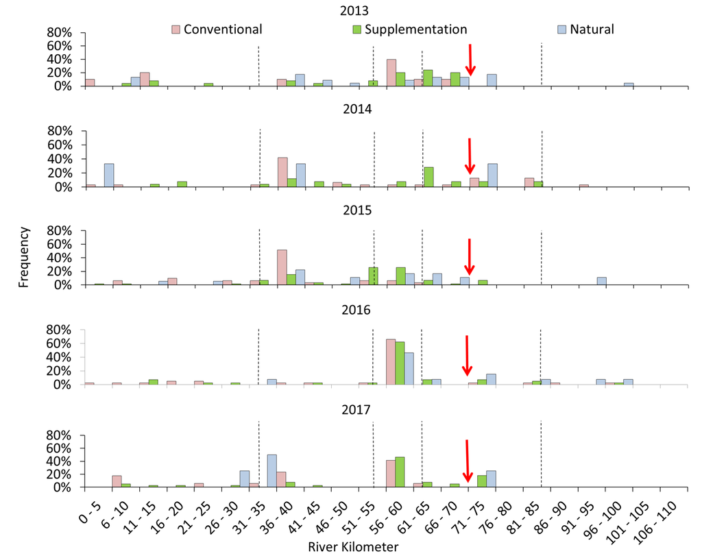

Figure 1.1: Estimated spawning locations for adult steelhead in the South Fork Clearwater River from a radio telemetry study conducted in 2013 - 2017.

This report provides a preliminary assessment of adult steelhead passage at the putative velocity barrier based on detections of PIT-tagged adults in the South Fork Clearwater River, including at sites SC3 and SC4 located downstream and upstream of the reach, respectively. PIT-tagged individuals include adults newly tagged at Lower Granite Dam plus individuals tagged and released as juveniles at various locations including within the South Fork Clearwater River. In particular, we’re interested in whether returning PIT-tagged adult observations suggest that adults passing SC3 “convert” to locations upstream of the barrier (e.g., SC4), suggesting that the barrier hinders or prevents passage at least for some adults. We also evaluate factors like juvenile release locations and discharge and their relation to conversion rates. Although the evaluation is focused on steelhead, we include data from PIT-tagged adult sp/sum Chinook salmon for comparison.

To support these efforts, the number of PIT-tagged juvenile steelhead within Newsome Creek releases was increased starting in 2022 (Table 1.1). Initial 1-ocean adults from those releases will begin returning to the South Fork Clearwater River to spawn in spring 2024.

Table 1.1: Number of PIT-tagged juveniles released (or anticipated) within Newsome Creek releases by year, including years that each release group will return to spawn.

| Release Site | Release Year | Tag Count | SW Age 1 SY | SW Age 2 SY |
| --- | --- | --- | --- | --- |
| NEWSOC | 2014 | 1496 | 2016 | 2017 |
| NEWSOC | 2015 | 1501 | 2017 | 2018 |
| NEWSOC | 2016 | 5980 | 2018 | 2019 |
| NEWSOC | 2018 | 2590 | 2020 | 2021 |
| NEWSOC | 2019 | 2535 | 2021 | 2022 |
| NEWSOC | 2020 | 2563 | 2022 | 2023 |
| NEWSOC | 2021 | 5989 | 2023 | 2024 |
| NEWSOC | 2022 | 15689 | 2024 | 2025 |
| NEWSOC | 2023 | 15866 | 2025 | 2026 |
| NEWSOC | 2024 | 15900 | 2026 | 2027 |
| NEWSOC | 2025 | 15900 | 2027 | 2028 |
| NEWSOC | 2026 | 15900 | 2028 | 2029 |

This preliminary evaluation is intended to evaluate adult conversion rates up-to-date since the SC3 and SC4 sites were installed in 2021 and to provide the baseline monitoring for responses to conversion rates if and when actions are taken to alleviate barriers in the study reach. This evaluation is preliminary and ongoing and will continue to be updated as additional years of data are collected and analyses are revised to address research and management questions.

## 1.1 Study area

The section of river considered to be a potential velocity barrier is located near rkm 71 of the South Fork Clearwater River (Figures 1.2 and 1.3). Figure 1.2 and Table 1.2 show each of the instream PIT tag detection sites (IPTDS) used in the evaluation to detect tagged adult steelhead and sp/sum Chinook salmon, including their rkm from the mouth of the South Fork Clearwater River.

[figure not shown]

Figure 1.2: Map of the study area including the locations of each instream PIT tag detection system and the approximate location of the potential velocity barrier shown in red.

Table 1.2: Instream PIT Tag Detection sites used in the evaluation including site codes, names, river kilometer (rkm) from the mouth of the SF Clearwater River, and location.

| Site | Name | rkm | Latitude | Longitude |
| --- | --- | --- | --- | --- |
| SC1 | Lower SF Clearwater R at rkm 1 | 1 | 46.13702 | -115.9813 |
| SC2 | Lower SF Clearwater R at rkm 2 | 2 | 46.12721 | -115.9778 |
| SC3 | South Fork Clearwater Site 3 | 60 | 45.81415 | -115.8160 |
| SC4 | South Fork Clearwater Site 4 | 81 | 45.82350 | -115.6341 |
| CRA | Crooked River Array | 94 | 45.82149 | -115.5277 |

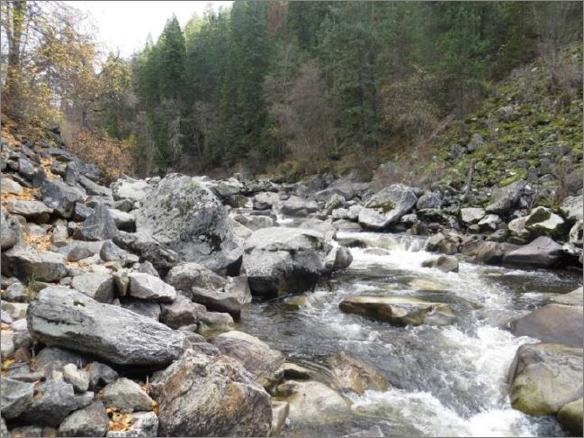

Figure 1.3: Photograph of the putative velocity barrier located near river kilometer 71 on the South Fork Clearwater River.

# 2 Evaluation

## 2.1 Data

Our evaluation used information from PIT-tagged adult steelhead and sp/sum Chinook salmon detected at any IPTDS in the South Fork Clearwater River during their upstream migration to spawn. We queried [DART](https://www.cbr.washington.edu/dart) to identify all PIT tags observed at Lower Granite Dam in returning adult steelhead and sp/sum Chinook salmon, during spawn years 2022 - 2024, using the `queryObsDART()` function in the R package `PITcleanr`, and filtered those observations to identify any adult later observed at any IPTDS in the South Fork Clearwater River (Table 1.2). Note that the adult detection rates on the Lower Granite Dam adult fish ladder are essentially 100%, and thus, any PIT-tagged adult returning to the South Fork Clearwater River is expected to not be “missed”. We then used the PIT-tag lists of returning adults to the South Fork Clearwater and queried their complete tag histories in [PTAGIS](https://www.ptagis.org/) which includes their mark and release information and any subsequent observations. The complete tag histories were then “compressed” and “filtered” using the `compress()` and `filterDetections()` functions in `PITcleanr`, respectively. For steelhead, we removed any detections after May 31 during the spawn year and for sp/sum Chinook salmon after September 15 to avoid detections of any kelts (steelhead only), shed tags, etc. Additionally, biological (e.g., sex, length) data for adults tagged at Lower Granite Dam are available from the Lower Granite Dam trapping database (LGTrappingDB). Additional data used in the evaluation (e.g., discharge) are described below. All data and code used in this evaluation are available at a GitHub site [here](https://github.com/NPTfisheries/SF_Clearwater_Passage).

## 2.2 Conversion Rates

First, we estimated annual conversion rates from SC3 to SC4 for steelhead and sp/sum Chinook salmon 2.1). The conversion rate provides an estimate of the percentage of PIT-tagged adults passing SC3 that arrived at SC4. For example, in spawn year 2024, we estimated that 140 PIT-tagged steelhead passed SC3, of which 13 (9.3%) were estimated to pass SC4. Table 2.1 provides the estimated number of tags passing both SC3 and SC4 and estimated conversion rates with standard error. Here, both natural- and hatchery-origin adults, including all release locations, are lumped.

Table 2.1: Estimated tags observed at SC3 and SC4 by species and spawn year including conversion rates.

| Species | Spawn Year | Est Tags SC3 | Est Tags SC4 | Conversion (%) | Conversion SE |
| --- | --- | --- | --- | --- | --- |
| Chinook | 2022 | 138 | 130 | 94.2 | 12.2 |
| Chinook | 2023 | 108 | 99 | 91.7 | 13.9 |
| Steelhead | 2022 | 108 | 15 | 13.9 | 27.6 |
| Steelhead | 2023 | 77 | 12 | 15.6 | 31.0 |
| Steelhead | 2024 | 140 | 13 | 9.3 | 29.0 |

Conversion rates from SC3 to SC4 were above 90% for sp/sum Chinook salmon; however, conversion rates for steelhead were all below 20% (Figure 2.1).

[figure not shown]

Figure 2.1: Conversion rates for sp/sum Chinook salmon and steelhead from SC3 to SC4 on the South Fork Clearwater River.

Estimates of conversion rates can be confounded for several reasons. For example, most sp/sum Chinook salmon in the South Fork Clearwater River originate from tributaries upstream of the high-velocity reach whereas many steelhead originate from juvenile releases downstream of the reach. As such, it is expected that sp/sum Chinook salmon will have higher conversion rates due to their proclivity to migrate to their upstream natal areas.

## 2.3 Release Groups

Because overall conversion rates from SC3 to SC4 can be confounded depending on where juveniles were released relative to the barrier reach (and their resulting “impetus” to pass the barrier), we next considered conversion rates for adult steelhead and whether they were released as juveniles downstream or upstream of the barrier. For steelhead, all upstream releases are from Newsome Creek releases. Table (2.2) shows the release location for all adults observed at IPTDS sites in the South Fork Clearwater; adults of unknown release location are oftentimes adults newly tagged at Lower Granite Dam.

Table 2.2: Summary of release location relative to the barrier reach for adult steelhead and sp/sum Chinook salmon observed at IPTDS sites in the South Fork Clearwater River.

| Species | Spawn Year | Downstream | Unknown | Upstream |
| --- | --- | --- | --- | --- |
| Chinook | 2022 | 16 | 156 | 29 |
| Chinook | 2023 | 16 | 107 | 36 |
| Steelhead | 2022 | 49 | 293 | 6 |
| Steelhead | 2023 | 107 | 465 | 16 |
| Steelhead | 2024 | 68 | 471 | 48 |

Due to lower sample sizes of adults observed at SC3 and SC4 within years, we lumped across spawn years and summarized conversion rates by juvenile release locations (Table 2.3; Figure 2.2). To date, 70 adults from Newsome Creek have been observed at IPTDS within the South Fork Clearwater River, of which 41 have been observed at SC3 and eight observed at SC4. Although sample sizes are low, conversion rates for Newsome Creek releases do appear somewhat higher than downstream and unknown releases; however, rates are still substantially lower than for sp/sum Chinook salmon.

Table 2.3: Summary of conversion rates for adult sp/sum Chinook salmon and steelhead based on whether their juvenile release location was upstream or downstream of the barrier reach (or unknown).

| Species | Release Location | Obs Tags | Obs Tags SC3 | Obs Tags SC4 | Est Tags SC3 | Est Tags SC4 | Conversion (%) |
| --- | --- | --- | --- | --- | --- | --- | --- |
| Chinook | Downstream | 32 | 9 | 8 | 9.3 | 9.4 | 100.0 |
| Chinook | Unknown | 263 | 176 | 148 | 179.9 | 171.7 | 95.4 |
| Chinook | Upstream | 65 | 60 | 45 | 61.0 | 51.4 | 84.2 |
| Steelhead | Downstream | 224 | 13 | 0 | 14.9 | 0.0 | 0.0 |
| Steelhead | Unknown | 1229 | 234 | 29 | 275.4 | 33.4 | 12.1 |
| Steelhead | Upstream | 70 | 41 | 8 | 42.9 | 8.0 | 18.6 |

[figure not shown]

Figure 2.2: Conversion rates for sp/sum Chinook salmon and steelhead from SC3 to SC4 on the South Fork Clearwater River, by release location relative to the barrier reach.

## 2.4 Discharge

Timm et al. (2018) indicated that at discharges exceeding approximately 1,000 cfs within the reach of interest, at least one very high velocity barrier emerges which exceeds burst swimming velocities for a 90 cm steelhead. Moreover, NPT personnel previously hypothesized that a barrier emerged within the reach when discharges exceed approximately 600 cfs at the previous Elk City gage. Although discharges are not currently measured in the barrier reach, flow within the reach is estimated to be approximately two times flow at the Elk City gage; and thus, when flows in the barrier reach are 1,000 cfs, flow at the Elk City gage would be approximately 500 cfs (Timm et al., 2017). Therefore, we estimated conversion rates from SC3 to SC4 when estimated flows at the Elk City gage are above or below 500 cfs (Table 2.4, Figure 2.4).

[figure not shown]

Figure 2.3: Linear regression of discharge (cfs) at the previous Elk City (13337500) gage with discharge at the Stites (13338500) gage.

Conversion rates when estimated discharges at Elk City were above 500 cfs (~ 1,000 cfs in the barrier reach) were lower than when estimated discharge was below 500 cfs (Table 2.4, Figure 2.4). Because we don’t actually know the cfs when the adult approached the barrier reach, we used the estimated cfs at the Elk City gage when each fish was most recently detected at an IPTDS site in the South Fork Clearwater River.

Table 2.4: Summary of conversion rates for adult steelhead based on discharge estimated at the previous Elk City gage.

| Species | Release Location | Est CFS (Elk City) | Obs Tags | Obs Tags SC3 | Obs Tags SC4 | Est Tags SC3 | Est Tags SC4 | Conversion (%) |
| --- | --- | --- | --- | --- | --- | --- | --- | --- |
| Steelhead | Downstream | abv_500 | 11 | 10 | 0 | 11.3 | 0.0 | 0.0 |
| Steelhead | Unknown | abv_500 | 132 | 105 | 4 | 115.2 | 4.4 | 3.8 |
| Steelhead | Upstream | abv_500 | 26 | 25 | 3 | 26.9 | 3.0 | 11.1 |
| Steelhead | Downstream | blw_500 | 213 | 3 | 0 | 3.6 | 0.0 | 0.0 |
| Steelhead | Unknown | blw_500 | 1097 | 129 | 25 | 160.2 | 29.0 | 18.1 |
| Steelhead | Upstream | blw_500 | 44 | 16 | 5 | 16.0 | 5.0 | 31.2 |

[figure not shown]

# 3 Discussion

The number of PIT-tagged juvenile steelhead within Newsome Creek releases was increased starting in spring 2022 (Table 1.1); 1-ocean adults from spring 2022 releases began returning to the South Fork Clearwater River in spring 2024 and we did observe a 3-fold increase in adults returning from those releases as expected. Two-ocean adults will begin returning in spring 2025; increased sample sizes and observations in future years will increase our ability to evaluate conversion rates in future years. Regardless, we have established monitoring for if and when restoration actions take place to address potential passage issues due to high stream velocities.

Our evaluation used season-long estimates of detection efficiencies to expand observed tags into estimates of tags passing each IPTDS, which in turn was used to estimate conversion rates. We recognize that detection efficiencies of IPTDS can be influenced by factors including river depth or dishcarge; however, we used season-wide estimates largely due to lower sample sizes at more extreme flows. We will explore stratifying estimates of detection efficiency for future years if increased PIT-tag returns allows.

# 4 Literature Cited

Cleary, P., 2019. Clearwater River B-Run Steelhead Supplementation Monitoring Project 2018 Progress Report: January 1 to December 31, 2018. Project Number 2010-057-00.

Timm, R., Caldwell, L., Stroud, D., Roni, P., Nelson, A., Long, C., 2017. South Fork Clearwater River, MP 28 Hypothesized Velocity Barrier, Final Report. Cramer Fish Sciences.

Timm, R., Ross, K., Muller, A., Caldwell, L., Nelson, A., Long, C., 2018. South Fork Clearwater River, MP 28 Hypothesized Velocity Barrier - Phase 2, Heuristic Modeling Exercise Addendum Technical Memo. Cramer Fish Sciences.

# 5 IPTDS Detection Probabilities

Table 5.1: Estimated season-wide detection probabilities for IPTDS located on the South Fork Clearwater River by species and year.

| Species | Spawn Year | Site | Obs Tags | Obs Tags Above | Resighted Tags | Detection Prob (%) | Detection SE |
| --- | --- | --- | --- | --- | --- | --- | --- |
| Chinook | 2022 | SC1 | 174 | 170 | 146 | 85.7 | 1.1 |
| Chinook | 2023 | SC1 | 149 | 141 | 132 | 93.7 | 0.7 |
| Chinook | 2022 | SC2 | 105 | 137 | 72 | 52.8 | 2.4 |
| Chinook | 2023 | SC2 | 112 | 108 | 79 | 73.2 | 2.3 |
| Chinook | 2022 | SC3 | 133 | 110 | 106 | 96.4 | 0.8 |
| Chinook | 2023 | SC3 | 108 | 91 | 91 | 100.0 | 0.0 |
| Chinook | 2022 | SC4 | 108 | 11 | 9 | 83.1 | 9.8 |
| Chinook | 2023 | SC4 | 90 | 10 | 9 | 90.9 | 7.9 |
| Steelhead | 2022 | SC1 | 328 | 269 | 251 | 93.2 | 0.7 |
| Steelhead | 2023 | SC1 | 575 | 498 | 487 | 97.8 | 0.2 |
| Steelhead | 2024 | SC1 | 547 | 388 | 349 | 90.0 | 0.9 |
| Steelhead | 2022 | SC2 | 245 | 71 | 47 | 66.6 | 4.9 |
| Steelhead | 2023 | SC2 | 486 | 77 | 65 | 84.5 | 3.8 |
| Steelhead | 2024 | SC2 | 319 | 140 | 71 | 51.0 | 3.7 |
| Steelhead | 2022 | SC3 | 66 | 12 | 7 | 61.1 | 11.9 |
| Steelhead | 2023 | SC3 | 77 | 12 | 12 | 100.0 | 0.0 |
| Steelhead | 2024 | SC3 | 140 | 13 | 13 | 100.0 | 0.0 |
| Steelhead | 2022 | SC4 | 11 | 3 | 2 | 73.3 | 17.1 |
| Steelhead | 2023 | SC4 | 12 | 3 | 3 | 100.0 | 0.0 |
| Steelhead | 2024 | SC4 | 13 | 2 | 2 | 100.0 | 0.0 |